# Black Lives Matter Media Analysis

J. Nathan Matias ([blog](https://civic.mit.edu/blog/natematias)) (/u/natematias) ([twitter](https://twitter.com/natematias)).

July 26, 2017

## Hypotheses

*H1. CHANCE OF COVERAGE*: Unarmed black people killed by the police received more coverage in the news after the death of Michael Brown, a change declined over time.

- H1A. The chance that an unarmed black person killed by the police would receive at least one news story about them increased after the death of Michael Brown.
- H1B. The incidence rate of news stories published about an unarmed black person killed by the police increased after the death of Michael Brown and declined from that point onward.

*H2. FRAMING*: News stories about unarmed black people killed by the police were more likely to frame those deaths in terms of a systemic issue, as measured by the number of other previous deaths mentioned in the article.

- H2A: The chance that an article mentioned at least one other victim increased after the death of Michael Brown
- H2B: The incidence rate of articles framed as a systemic issue increased after the death of Michael Brown and declined from that point onward

## Data Collection

The dataset of unarmed black people killed by the police or who died in police custody (people) includes a total of 343 people killed from Jan 04, 2013 to Jun 29, 2016. Within this dataset, Michael Brown’s death occurred on Aug 09, 2014, the 581th day in the dataset. After removing Michael Brown and any people killed in the 14 day period before and including the day of his death, our dataset includes 333 people.

In our analysis of media coverage received by people’s deaths (H1), our dependent variable is the number of articles about a victim in the 14 days after their death. We also observe the binary measure of whether the victim was mentioned in any articles in our sample during the same period. ince MediaCloud may collect varying percentages of the available articles, and since the output of articles by publishers varies over time, we normalize this measure by dividing the raw by the number of articles observed on MediaCloud that day

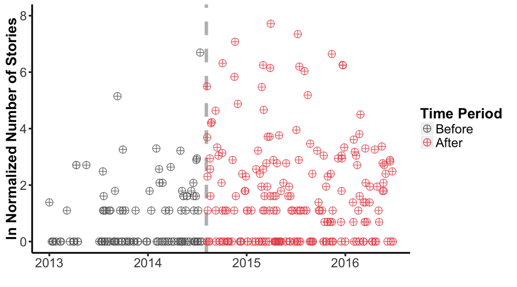

```r
ggplot(people, aes(x = day.num, y=log1p(normalized.stories))) +
  geom_vline(xintercept=c(brown.day.num), linetype="dashed", size=2, color="gray") +
  geom_point(data=subset(people, day.num<(brown.day.num-14)), aes(color="gray40"), shape=10, size=4) +
  geom_point(data=subset(people, day.num>brown.day.num), aes(color="red"), shape=10, size=4) +
  ylab("ln Normalized Number of Stories") +
  ylim(0,8) +
  scale_x_continuous(name ="",breaks=c(0,365,730,1095),
                     labels=c("2013", "2014", "2015", "2016")) +
  scale_colour_manual(name = 'Time Period',
                      values =c('gray40'='gray40','red'='#E95556'), labels = c('Before','After')) +
  theme(panel.grid.major = element_blank(), panel.grid.minor = element_blank(),
        panel.background = element_blank(), axis.line.x = element_line(size=1, colour = "black"),
        axis.line.y = element_line(size=1, colour = "black"), axis.ticks = element_line(size=1),
        axis.ticks.length = unit(.15, "cm"),
        axis.text=element_text(size=16),
        axis.title=element_text(size=18,face="bold"),
        legend.title = element_text(colour="black", size=18, face="bold"),
        legend.text = element_text(colour="black", size = 16))
```

```r
pander(CrossTable(people$after.brown,people$any.articles,
           expected=FALSE, prop.r=TRUE, prop.c=FALSE,
           prop.t=FALSE, prop.chisq=FALSE, digits = 1))
```

| people$after.brown | people$any.articles FALSE | TRUE | Total |
| --- | --- | --- | --- |
| **0** N Row(%) | 68 60.18% | 45 39.82% | 113 33.93% |
| **1** N Row(%) | 80 36.36% | 140 63.64% | 220 66.07% |
| Total | 148 | 185 | 333 |

Within the dataset of people, we also observe the number of days that elapsed since the first observation in the dataset (day.num), as well as whether a person was killed in the period after Michael Brown’s death (after.brown). We record the male or female gender of the victim, as reported in the news articles, their age, and the log-transformed population of the metropolitan area where the person was killed (ln.population).

In our story-level analysis (H2), our dependent variable is the count of sentences in the story that mention at least one prior victim in the dataset (sentences.about.others), as well as a binary measure of whether any sentence in the article mentioned any other prior victim (wider.issue).

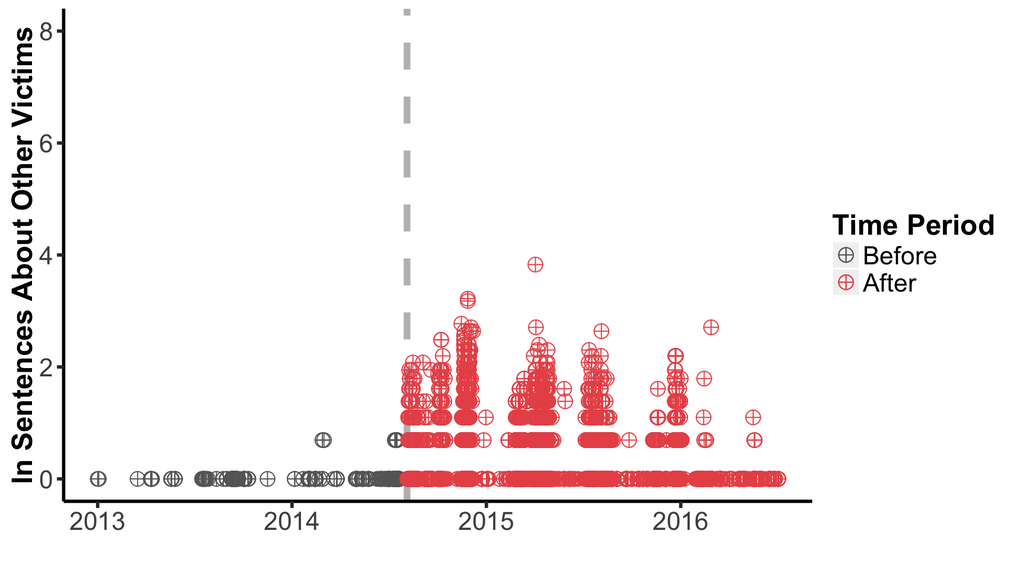

```r
ggplot(stories, aes(x = story.day.num, y=log1p(sentences.about.others))) +
  geom_vline(xintercept=c(brown.day.num), linetype="dashed", size=2, color="gray") +
  geom_point(data=subset(stories, story.day.num<(brown.day.num-14)), aes(color="gray40"), shape=10, size=4) +
  geom_point(data=subset(stories, story.day.num>brown.day.num), aes(color="red"), shape=10, size=4) +
  ylab("ln Sentences About Other Victims") +
  ylim(0,8) +
  scale_x_continuous(name ="",breaks=c(0,365,730,1095),
                     labels=c("2013", "2014", "2015", "2016")) +
  scale_colour_manual(name = 'Time Period',
                      values =c('gray40'='gray40','red'='#E95556'), labels = c('Before','After')) +
  theme(panel.grid.major = element_blank(), panel.grid.minor = element_blank(),
        panel.background = element_blank(), axis.line.x = element_line(size=1, colour = "black"),
        axis.line.y = element_line(size=1, colour = "black"), axis.ticks = element_line(size=1),
        axis.ticks.length = unit(.15, "cm"),
        axis.text=element_text(size=16),
        axis.title=element_text(size=18,face="bold"),
        legend.title = element_text(colour="black", size=18, face="bold"),
        legend.text = element_text(colour="black", size = 16))
```

```r
pander(CrossTable(stories$after.brown,stories$wider.issue,
                  expected=FALSE, prop.r=TRUE, prop.c=FALSE,
                  prop.t=FALSE, prop.chisq=FALSE, digits = 1))
```

| stories$after.brown | stories$wider.issue FALSE | TRUE | Total |
| --- | --- | --- | --- |
| **0** N Row(%) | 730 97.33% | 20 2.67% | 750 6.75% |
| **1** N Row(%) | 7966 76.86% | 2398 23.14% | 10364 93.25% |
| Total | 8696 | 2418 | 11114 |

## Findings

### Changes in News Coverage

#### Chance of News Coverage

To test the hypothesis of an increase in news coverage after the death of Michael Brown, we use a logistic regression model to estimate the chance that a person killed by the police or who died in their custody would have at least one article mention their name. To improve the precision of our estimate of the difference, we include regression adjustments for the gender of the person as reported in the news, their reported age, and the population of metropolitan area where their death occurred.

We find that in the 580 days before Michael Brown’s death, a 33 year old black male killed by the police in a city with the median population had a 39.34% chance of having at least one article published about them, on average. In the 691 days after Brown’s death, a similar person had a 64.25% chance of having an article published about them on average, a statistically-significant difference of 24.92 percentage pionts (p=0.00003).

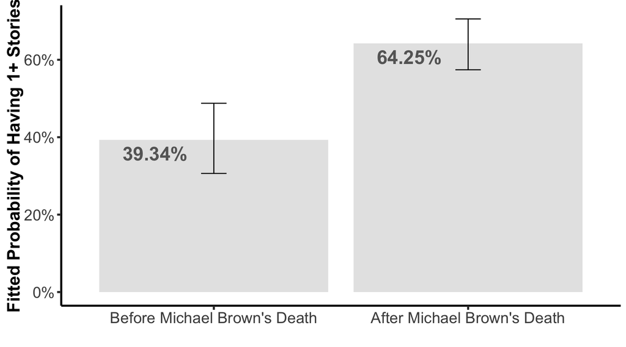

```r
ggplot(data.h1a, aes(factor(after.brown), dv)) +
  geom_bar(stat="identity", fill='gray90') +
  ylab("Fitted Probability of Having 1+ Stories") +
  scale_y_continuous(labels = scales::percent) +
  geom_text(aes(label=sprintf("%1.2f%%", 100*dv)), vjust=1.5, hjust=1.4,
            size=7, color="gray40", fontface="bold") +
  scale_x_discrete("", labels = c("Before Michael Brown's Death","After Michael Brown's Death")) +
  geom_errorbar(aes(ymin = lwr, ymax = upr), width=0.1) +
  theme(panel.grid.major = element_blank(), panel.grid.minor = element_blank(),
        panel.background = element_blank(), axis.line.x = element_line(size=1, colour = "black"),
        axis.line.y = element_line(size=1, colour = "black"), axis.ticks = element_line(size=1),
        axis.ticks.length = unit(.15, "cm"),
        axis.text=element_text(size=16),
        axis.title=element_text(size=18,face="bold"),
        legend.title = element_text(colour="black", size=18, face="bold"),
        legend.text = element_text(colour="black", size = 16))
```

```r
htmlreg(h1a, digits=3, label="table:comment.effect",
          custom.model.names=c("Modeling Chance of Coverage"),
          custom.coef.names = c("Intercept", "Age",
                                "Gender (Male)","ln Population", "After Brown's Death"),
          caption="Using a logistic regression, we find that in the period after Michael Brown's death, an unarmed black person killed by the police had a 24.9 percentage point greater chance of having at least one article published about them.", star.symbol = "\\*",
          inline.css = TRUE, doctype = FALSE, html.tag = FALSE, head.tag = FALSE, body.tag = FALSE)
```

Using a logistic regression, we find that in the period after Michael Brown’s death, an unarmed black person killed by the police had a 24.9 percentage point greater chance of having at least one article published about them.

|  | **Modeling Chance of Coverage** |
| --- | --- |
| Intercept | -1.309 |
|  | (0.854) |
| Age | -0.010 |
|  | (0.010) |
| Gender (Male) | -0.063 |
|  | (0.446) |
| ln Population | 0.107 |
|  | (0.055) |
| After Brown’s Death | 1.020*** |
|  | (0.242) |
| AIC | 445.544 |
| BIC | 464.585 |
| Log Likelihood | -217.772 |
| Deviance | 435.544 |
| Num. obs. | 333 |
| ***p < 0.001, **p < 0.01, *p < 0.05 |  |

#### Incidence Rate of News Coverage

We also test the hypothesis of an increase in the incidence rate of coverage of black people killed by the police, one that declines over time. To test this hypothesis, we use a negative binomial model that predicts the incidence rate of the normalized number of articles published about a person in the 14 day period after their death (Long, J. Scott). In the model, we test the hypothesis of a cubic relationship between the day count and the incidence rate, controlling for age, gender, and population:

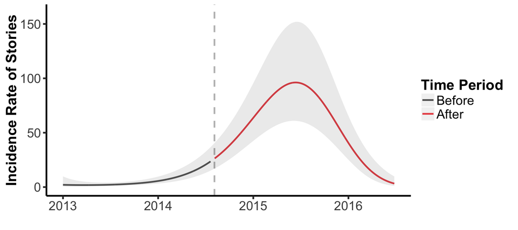

[output not shown]

```r
ggplot(data.h1b, aes(x = day.num, y=dv)) +
  geom_vline(xintercept=c(brown.day.num), linetype="dashed", size=1, color="gray") +
  geom_line(data=subset(data.h1b, day.num<(brown.day.num-14)),size = 1, aes(color="gray40")) +
  geom_line(data=subset(data.h1b, day.num>brown.day.num),size = 1, aes(color="red")) +
  geom_ribbon(aes(ymin=data.h1b$lwr, ymax=data.h1b$upr), alpha=0.1) +
  #  geom_point(data=people,aes(x=people$day.num, y=people$num_articles), alpha=.9, position=position_jitter(h=.2), color="red") +
  #  geom_text(data=people,aes(label=name), size=3, alpha=0.8) +
  #  geom_vline(xintercept=c(221,235), linetype="dotted") +
  ylab("Incidence Rate of Stories") +
  ylim(0,160) +
  scale_x_continuous(name ="",breaks=c(0,365,730,1095),
                     labels=c("2013", "2014", "2015", "2016")) +
  scale_colour_manual(name = 'Time Period',
                      values =c('gray40'='gray40','red'='#E95556'), labels = c('Before','After')) +
  theme(panel.grid.major = element_blank(), panel.grid.minor = element_blank(),
        panel.background = element_blank(), axis.line.x = element_line(size=1, colour = "black"),
        axis.line.y = element_line(size=1, colour = "black"), axis.ticks = element_line(size=1),
        axis.ticks.length = unit(.15, "cm"),
        axis.text=element_text(size=16),
        axis.title=element_text(size=18,face="bold"),
        legend.title = element_text(colour="black", size=18, face="bold"),
        legend.text = element_text(colour="black", size = 16))
```

### Frame Changes

#### Chance of Including A Wider Frame

To test the hypothesis of a change in the framing of stories after the death of Michael Brown, we use a logistic regression model to estimate the chance of a story to include a mention of at least one other person. To improve the precision of our estimate of the difference, we include regression adjustments for the gender of the person as reported in the news, their reported age, and the population of metropolitan area where their death occurred.

In a logistic regression mode on the 11,114 stories in our sample, in the 580 days before Michael Brown’s death, we find that for an unarmed, 33 year old black male killed by the police in a city of median size, a story had a 2.44% chance of mentioning a previous victim on average. In the 688 days after Michael Brown’s death, a similar story had a 20.71% chance of including at least one mention of another victim on average, an estimated difference of 18.26 percentage points.

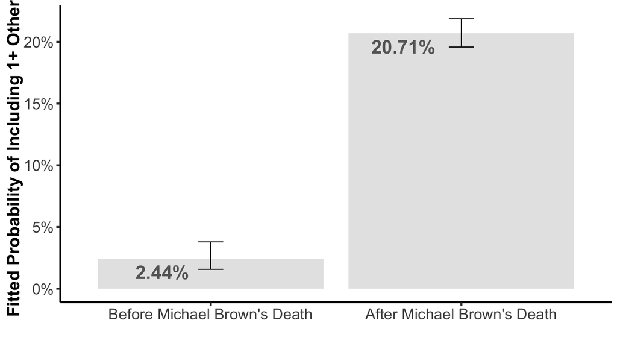

```r
ggplot(data.h2a, aes(factor(after.brown), dv)) +
  geom_bar(stat="identity", fill='gray90') +
  ylab("Fitted Probability of Including 1+ Others") +
  scale_y_continuous(labels = scales::percent) +
  geom_text(aes(label=sprintf("%1.2f%%", 100*dv)), vjust=1.5, hjust=1.4,
            size=7, color="gray40", fontface="bold") +
  scale_x_discrete("", labels = c("Before Michael Brown's Death","After Michael Brown's Death")) +
  geom_errorbar(aes(ymin = lwr, ymax = upr), width=0.1) +
  theme(panel.grid.major = element_blank(), panel.grid.minor = element_blank(),
        panel.background = element_blank(), axis.line.x = element_line(size=1, colour = "black"),
        axis.line.y = element_line(size=1, colour = "black"), axis.ticks = element_line(size=1),
        axis.ticks.length = unit(.15, "cm"),
        axis.text=element_text(size=16),
        axis.title=element_text(size=18,face="bold"),
        legend.title = element_text(colour="black", size=18, face="bold"),
        legend.text = element_text(colour="black", size = 16))
```

```r
htmlreg(h2a, digits=3, label="table:comment.effect",
          custom.model.names=c("Logistic Regression"),
          custom.coef.names = c("Intercept", "Age",
                                "Gender (Male)","ln Population", "After Brown's Death"),
          caption="In the period after Michael Brown's death, a story about an unarmed black person killed by the police had an 18.27 percentage point greater chance of including a mention of at least one other victim, on average",
          star.symbol = "\\*", inline.css = TRUE, doctype = FALSE,
          html.tag = FALSE, head.tag = FALSE, body.tag = FALSE)
```

In the period after Michael Brown’s death, a story about an unarmed black person killed by the police had an 18.27 percentage point greater chance of including a mention of at least one other victim, on average

|  | **Logistic Regression** |
| --- | --- |
| Intercept | -3.961*** |
|  | (0.340) |
| Age | -0.028*** |
|  | (0.002) |
| Gender (Male) | 0.398*** |
|  | (0.107) |
| ln Population | 0.065*** |
|  | (0.019) |
| After Brown’s Death | 2.344*** |
|  | (0.230) |
| AIC | 11159.988 |
| BIC | 11196.568 |
| Log Likelihood | -5574.994 |
| Deviance | 11149.988 |
| Num. obs. | 11114 |
| ***p < 0.001, **p < 0.01, *p < 0.05 |  |

#### Incidence Rate of Including Other Names

We also test the frame-change hypothesis by estimating changes in the incidence rate of mentions of other victims in stories, expecting that the rate would increase after the death of Michael Brown and declines over time. To test this hypothesis, we use a negative binomial model that predicts the incidence rate of sentences mentioning other victims, for stories published about a person in the 14 day period after their death (Long, J. Scott). In the model, we test the hypothesis of a cubic relationship between the day count and the incidence rate, as well as a change in that relationship after the death of Michael Brown, controlling for age, gender, and population:

In the model of stories per person (Table below), we find that the incidence rate of other victims mentioned in stories did increase after the death of Michael Brown to an estimate between 1.92 and 3.04. The rate then declined on average after Michael Brown’s death. By the end of our observation period, the incidence rate had declined to an estimated value of 0.17, which was still greater than the incidence rate of 0.00 at the beginning of the observation period, a difference that is statistically-significant.

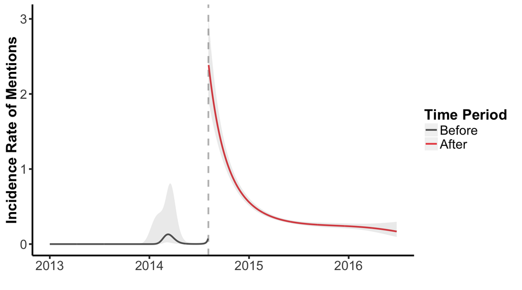

```r
ggplot(data.h2b, aes(x = story.day.num, y=dv)) +
  geom_vline(xintercept=c(brown.day.num), linetype="dashed", size=1, color="gray") +
  geom_line(data=subset(data.h2b, story.day.num<(brown.day.num)),size = 1, aes(color="gray40")) +
  geom_line(data=subset(data.h2b, story.day.num>brown.day.num),size = 1, aes(color="red")) +
  geom_ribbon(aes(ymin=data.h2b$lwr, ymax=data.h2b$upr), alpha=0.1) +
  #  geom_point(data=people,aes(x=people$day.num, y=people$num_articles), alpha=.9, position=position_jitter(h=.2), color="red") +
  #  geom_text(data=people,aes(label=name), size=3, alpha=0.8) +
  #  geom_vline(xintercept=c(221,235), linetype="dotted") +
  ylab("Incidence Rate of Mentions") +
  scale_x_continuous(name ="",breaks=c(0,365,730,1095),
                     labels=c("2013", "2014", "2015", "2016")) +
  scale_colour_manual(name = 'Time Period',
                      values =c('gray40'='gray40','red'='#E95556'), labels = c('Before','After')) +
  theme(panel.grid.major = element_blank(), panel.grid.minor = element_blank(),
        panel.background = element_blank(), axis.line.x = element_line(size=1, colour = "black"),
        axis.line.y = element_line(size=1, colour = "black"), axis.ticks = element_line(size=1),
        axis.ticks.length = unit(.15, "cm"),
        axis.text=element_text(size=16),
        axis.title=element_text(size=18,face="bold"),
        legend.title = element_text(colour="black", size=18, face="bold"),
        legend.text = element_text(colour="black", size = 16))
```

```r
htmlreg(h2b.model, digits=3, label="table:comment.effect",
          custom.model.names=c("Modeling Change in Framing"),
          custom.coef.names = c("Intercept", "Age",
                                "Gender (Male)","ln Population", "After Brown's Death",
                                "Story Day",  "Story Day ^2", "Story Day ^3",
                                "After Brown x Story Day",
                                "After Brown x Story Day ^2",
                                "After Brown x Story Day ^3"),
          caption="In the period after Michael Brown's Death, stories mentioned other victims at greater rates, a difference that declined but persisted over time.")
```

In the period after Michael Brown’s Death, stories mentioned other victims at greater rates, a difference that declined but persisted over time.

|  | **Modeling Change in Framing** |
| --- | --- |
| Intercept | -989.766** |
|  | (379.796) |
| Age | -0.044 |
|  | (0.124) |
| Gender (Male) | -0.011*** |
|  | (0.003) |
| ln Population | 0.037 |
|  | (0.022) |
| After Brown’s Death | 1011.867** |
|  | (379.820) |
| Story Day | 6.250** |
|  | (2.285) |
| Story Day ^2 | -0.013** |
|  | (0.005) |
| Story Day ^3 | 0.000** |
|  | (0.000) |
| After Brown x Story Day | -6.317** |
|  | (2.285) |
| After Brown x Story Day ^2 | 0.013** |
|  | (0.005) |
| After Brown x Story Day ^3 | -0.000** |
|  | (0.000) |
| AIC | 17058.156 |
| BIC | 17138.631 |
| Log Likelihood | -8518.078 |
| Deviance | 6328.304 |
| Num. obs. | 11114 |
| p < 0.001, p < 0.01, p < 0.05 |  |